# Chart types

# Overview

This document shows graphs of the following relationships.

1. Nominal comparison
2. Time series
3. Ranking
4. Part-to-whole
5. Deviation
6. Single distribution
7. Multiple distribution
8. Correlation
9. Geospatial

The graphs have these basic forms

1. Points
2. Lines
3. Bars
4. Boxes

Some graphs are suitable to show relationships, some are not. The notes below give details.

## Nominal comparison

Comparing nominals which have a numerical value associated with them. Bars and points work best. Avoid lines and boxes.

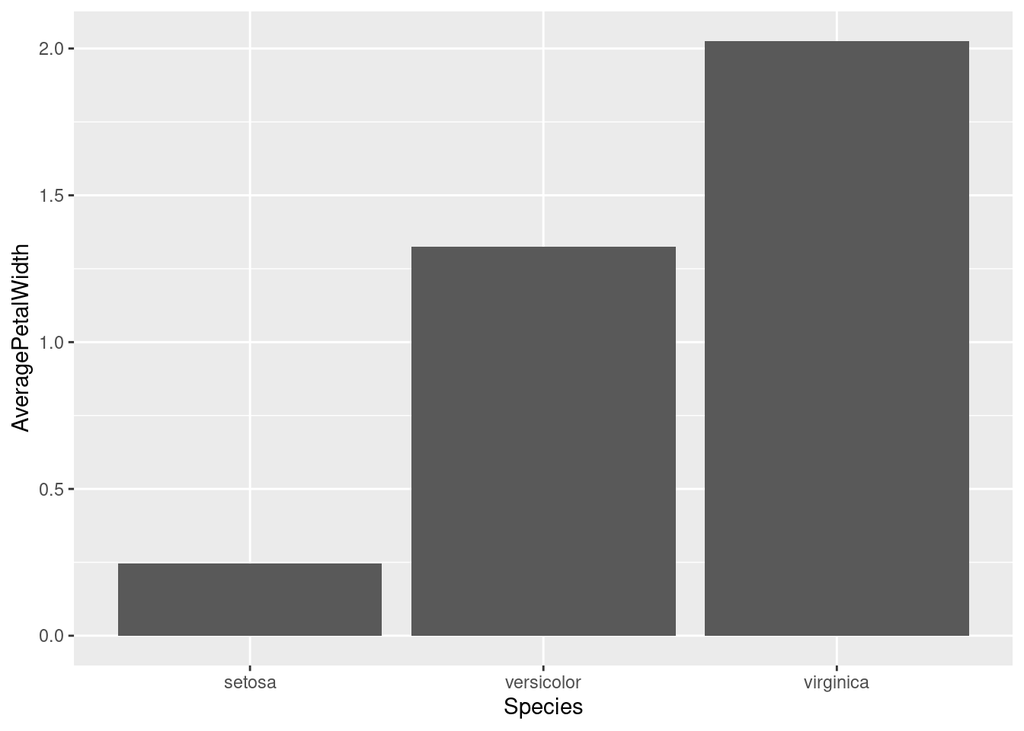

## Time series

Data that varies by time. Most graph types work for this sort of data. The key thing is to show how something varies by time.

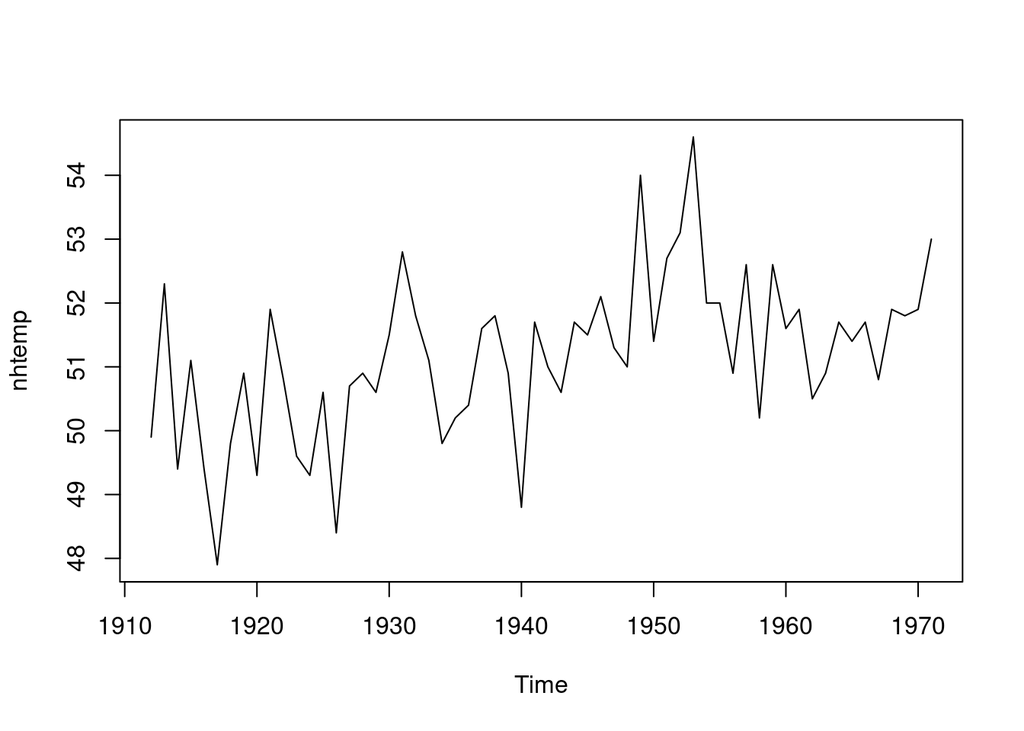

## Ranking

Comparisons between nominals but where the ordering is important. Bars are usually best. Ensure the ordering matches the rank.

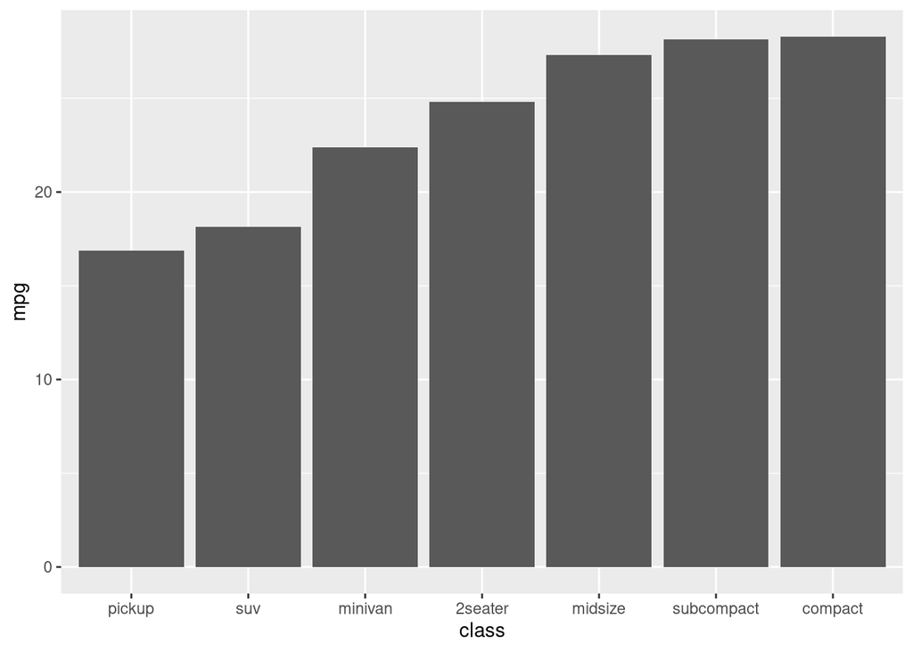

## Part-to-whole

These graphs relate parts of something to the whole. Avoid points and boxes.

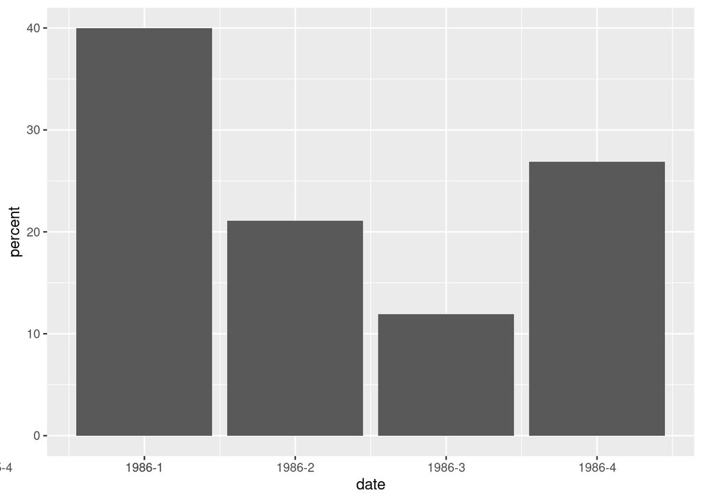

## Deviation

A deviation graph shows how values differ from a primary set of values. Lines and bars work well. Avoid boxes.

[figure not shown]

## Single distribution

This shows how a population of data values is distributed across all the data. Avoid box plots for single distributions.

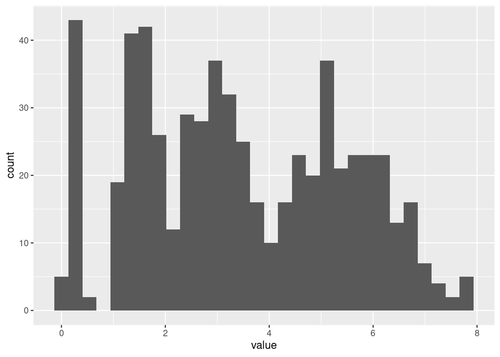

## Multiple distributions

When there are multiple groups within the data, each has a distribution. Avoid the following because it is hard to read.

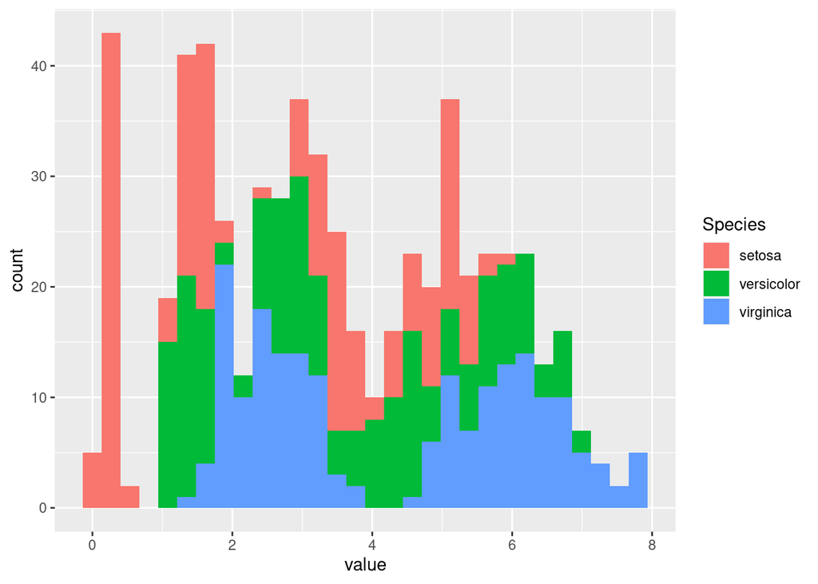

Instead try to show different graphs for each group but ensure alignments are done properly.

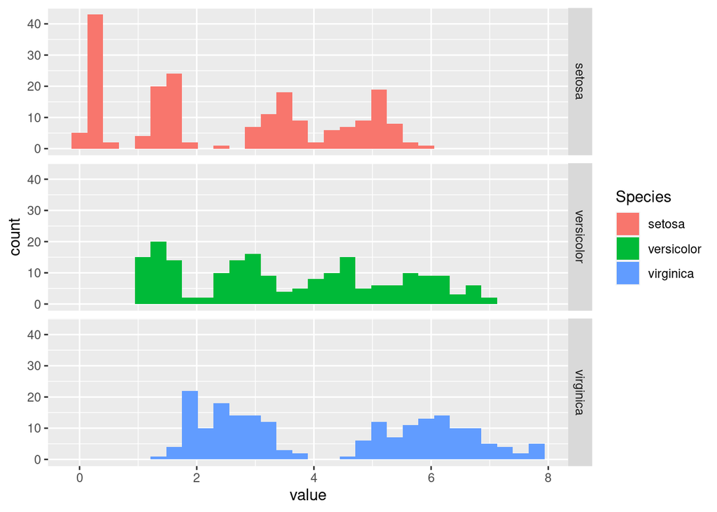

## Correlation

Correlation is used to illustrate how 2 variables depend on one another. Correlation coefficients need to be calculated to show how good the correlation is.

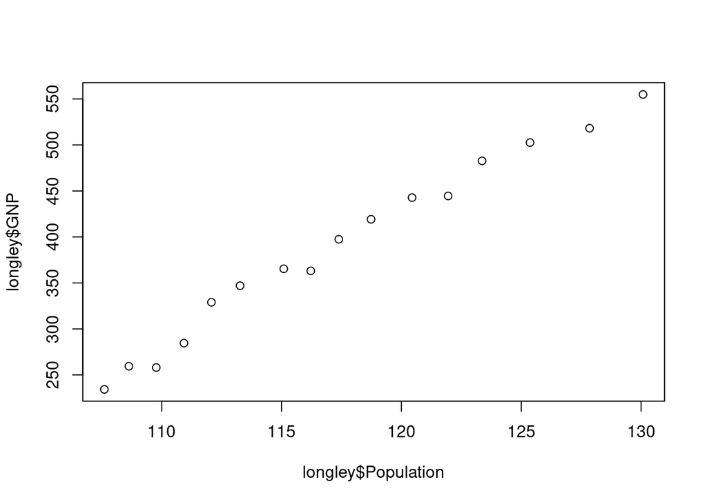

## Geospatial

Showing maps is often very powerful as it can draw out features that are not obvious. Try to avoid bars and boxes. Strive to show data points in different colours and size as well as colouring in geographical regions.

[interactive chart not shown]